# Piecewise Regression

Reference: https://www.r-bloggers.com/r-for-ecologists-putting-together-a-piecewise-regression/

First, let’s generate some segmented data:

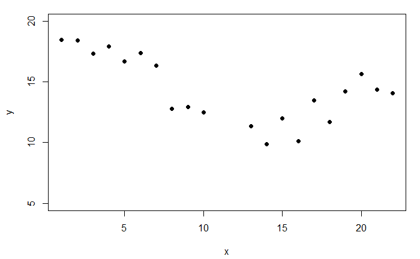

```r
x <- c(1:10, 13:22)
y <- numeric(20)
## Create first segment
y[1:10] <- 20:11 + rnorm(10, 0, 1.5)
## Create second segment
y[11:20] <- seq(11, 15, len=10) + rnorm(10, 0, 1.5)
## Plot it
par(mar=c(4,4,1,1)+0.2)
plot(x,y, ylim=c(5, 20), pch=16)
```

Data has a V-shaped plot, where the right side is a little shallower sloped.

# METHOD 1: ITERATIVE SEARCHING

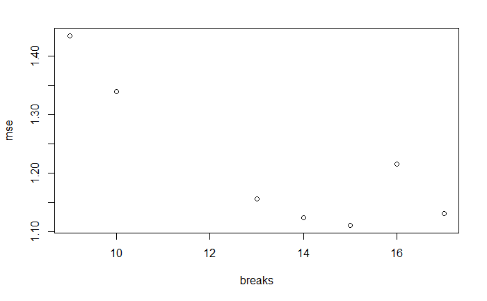

```r
breaks <- x[which(x >= 9 & x <= 17)]
mse <- numeric(length(breaks))
for(i in 1:length(breaks)){
 piecewise1 <- lm(y ~ x*(x < breaks[i]) + x*(x>=breaks[i]))
 mse[i] <- summary(piecewise1)[6]
}
mse <- as.numeric(mse)
plot(breaks, mse)
```

It is just pick the breakpoint with the lowest error:

```r
break.point = breaks[which(mse==min(mse))]
paste("Break point is", break.point)
```

```
[1] "Break point is 15"
```

```r
piecewise2 <- lm(y ~ x*(x < break.point) + x*(x > break.point))
summary(piecewise2)
```

```
Call:
lm(formula = y ~ x * (x < break.point) + x * (x > break.point))

Residuals:
    Min      1Q  Median      3Q     Max
-1.5673 -0.7189 -0.1981  0.7736  1.6494

Coefficients: (1 not defined because of singularities)
                      Estimate Std. Error t value Pr(>|t|)
(Intercept)             2.6259     3.3817   0.776 0.449530
x                       0.6253     0.2126   2.941 0.010118 *
x < break.pointTRUE    17.3313     3.4428   5.034 0.000148 ***
x > break.pointTRUE    -1.1435     1.4730  -0.776 0.449620
x:x < break.pointTRUE  -1.3279     0.2278  -5.830 3.31e-05 ***
x:x > break.pointTRUE       NA         NA      NA       NA
---
Signif. codes:  0 ‘***’ 0.001 ‘**’ 0.01 ‘*’ 0.05 ‘.’ 0.1 ‘ ’ 1

Residual standard error: 1.125 on 15 degrees of freedom
Multiple R-squared:  0.8679,    Adjusted R-squared:  0.8326
F-statistic: 24.63 on 4 and 15 DF,  p-value: 1.918e-06
```

```r
cf <- coef(piecewise2)
plot(x,y, ylim=c(5, 20), pch=16)
curve((cf[1] + cf[3]) + (cf[2] + cf[5])*x, add=T, from=1, to=break.point)
```

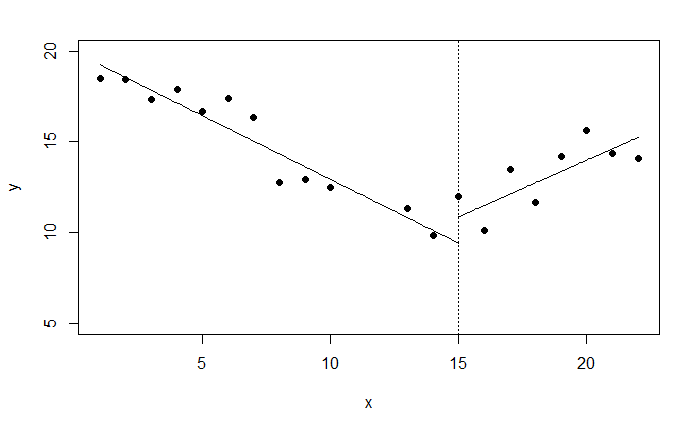

```r
curve((cf[1] + cf[4]) + cf[2]*x, add=T, from=break.point, to=max(x))
abline(v=break.point, lty=3)
```

Notice that the segments were not constrained to be touching or continuous. This is inherent in the algorithm that we used.

# METHOD 2: USE ‘SEGMENTED’ PACKAGE

To use this method, you first fit a generic linear model. You then use the segmented( ) function to fit the piecewise regression. The segmented( ) function takes for its arguments the generic linear model, seg.Z which is a one sided formula describing the predictor with a segment (we only have one predictor, x, which has the segment), and psi, which is a starting value of the breakpoint (as in nls( ), you need to supply a best-guess estimate). More complicated models are a bit more complicated in terms of arguments, but this is a good starting example.

In our case, x is the predictor with a segment (it’s the only predictor) and based on my very first scatterplot (the first graph on the page), I’m going to guess the breakpoint is 14.

```r
library(segmented)
lin.mod <- lm(y~x)
segmented.mod <- segmented(lin.mod, seg.Z = ~x, psi=14)
summary(segmented.mod)
```

```
    ***Regression Model with Segmented Relationship(s)***

Call:
segmented.lm(obj = lin.mod, seg.Z = ~x, psi = 14)

Estimated Break-Point(s):
   Est. St.Err
13.859  0.846

Meaningful coefficients of the linear terms:
            Estimate Std. Error t value Pr(>|t|)
(Intercept) 19.88471    0.68986  28.824 3.22e-15 ***
x           -0.68703    0.09721  -7.068 2.66e-06 ***
U1.x         1.28070    0.17463   7.334       NA
---
Signif. codes:  0 ‘***’ 0.001 ‘**’ 0.01 ‘*’ 0.05 ‘.’ 0.1 ‘ ’ 1

Residual standard error: 1.124 on 16 degrees of freedom
Multiple R-Squared: 0.8594,  Adjusted R-squared: 0.833

Convergence attained in 3 iterations with relative change 1.758284e-16
```

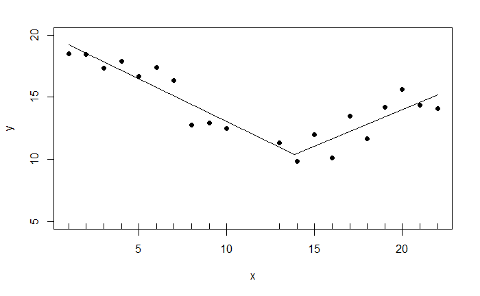

```r
plot(x,y, pch=16, ylim=c(5,20))
plot(segmented.mod, add=T)
```

There you go: two methods for piecewise regression. Each is relatively simple to implement, but they do very different things. If you are dead set on piecewise regression, make sure you choose the one that makes the most sense for your question: do the segments need to be continuous or can they be discontinuous? Make sure you have a rationale for either.

Also note that these models are not nested, so you can’t used likelihood ratio tests for model selection. You can try to use AIC for model selection, but I advise you to think logically about the continuity of the segments instead.